# The Dragon Phylogeny

# Overview

A phylogeny is a tree that represents a hypothesis about the evolutionary relationships among organisms. Connected branches form a ‘clade’ and shorter connections represent more recent evolutionary divergence compared to long (i.e. deep) branches. There are many different methods for building a phylogenetic tree, but in general, trees are built using clustering algorithms that group objects by some measure of their similarity. Modern phylogenies are based on DNA or protein similarity, but in principal we can cluster objects based on any trait we can measure. To look at the process in more detail, let’s do a phylogeny of dragons.

The **Dragon Phylogeny** is a project developed when [Rob Colautti](https://bit.ly/ColauttiLab) was a postdoctoral researcher at the University of British Columbia. It was originally developed as a t-shirt [Threadless.com](https://www.threadless.com/designs/dragon-phylogeny), which is out of print now.

**HOWEVER** Some recent students have resurrected the project and re-released a slightly different version, which is available at https://dragonphylogeny.threadless.com/ 100% of proceeds support the project.

The original design generated some media coverage:

- [io9/Gizmodo Article](https://io9.gizmodo.com/5936427/the-evolutionary-history-of-dragons-illustrated-by-a-scientist) – A nice write-up about the project on the blog io9.com (now part of Gizmodo).
- [CBC.ca Interview](http://www.cbc.ca/news/canada/british-columbia/dragon-family-tree-springs-from-scientist-s-imagination-1.1218358) – from an interview with CBC radio, later posted on their website.

## GitHub

The project now lives on at GitHub: https://github.com/ColauttiLab/DragonPhylogeny

# Scoring Traits

## Images

The images are available as a pdf file on the Dragon Phylogeny GitHub site: Dragon_Pics.pdf **NOTE** This is a large file size (9.4MB). The PDF contains images of all dragons used in the original Dragon Phylogeny Unfortunately, we don’t have any dragon blood to do a DNA-based phylogeny. However, we can try to cluster dragons based on their physical appearance. The first step is to locate some pictures of dragons and choose a common set of traits.

Here are the traits for a variety of dragons:

| Origin | RefNum | Teeth.Type | Tongue | Eyes | Eye.position | Ears | Nose | Snout | Horns | Skin.face.neck | Skin.body | Skin.Belly | Dorsal.ridge | Toes | Opposed.toes | Legs | Claws | Wings | Wing.type | Wing.structure | Body.Type | Tail.end | Size | wiskers |
| --- | --- | --- | --- | --- | --- | --- | --- | --- | --- | --- | --- | --- | --- | --- | --- | --- | --- | --- | --- | --- | --- | --- | --- | --- |
| German | 1 | Blunt | forked; short | small | lateral | spearlike | upturned; forward nostrils | long | absent | smooth | fish scales | wide platemail | absent | 3 | 0 | 4 | short catlike | 2 | bat-like | 4 ridges | elongate | point |  | absent |
| French | 2 | Fangs | forked; long | average | lateral | absent | upturned; forward nostrils | long | plates | hairy | soft scales | hair | absent | 3 | 1 | 4 | short talon | 2 | bird-like |  | elongate | point | 1-2x human | absent |
| French | 3 | Blunt&Fangs | wormy; short |  | forward | spearlike | pointy; forward nostrils | long | absent | smooth | smooth | smooth | absent | 3 | 0 | 4 | short catlike | 2 | bat-like | 11 ridges | rotund | point | 1-2x human | absent |
| Dutch | 4 | Pointy |  | narrow | lateral | spearlike | upturned; forward nostrils | moderate | absent | scaly skin | round platemail | smooth | single row; spikes | 3 | 1 | 4 | short talon | 2 | bird-like | 5major; 6minor ridges |  |  |  | absent |
| English | 5 |  |  | small | lateral | absent | upturned; lateral nostrils | long | absent | smooth | smooth | smooth | single row; continuous | 2 | 0 | 4 |  | 2 | batlike | 5 ridges | elongate | point | 1-2x human | absent |
| American | 6 | Pointy | single; long | large | lateral | absent | slits; forward | absent | absent | scaly skin | hexagonal scales | wide platemail | absent | 0 | 0 | 0 | 0 | 0 | 0 | 0 | snake |  | 3x human | absent |
| French | 7 | Blunt&Fangs | forked; long | small | forward | spearlike | upturned; forward nostrils | blunt | absent | hairy | rough | wide platemail |  | 4 | 1 | 4 | large talon | 2 | mix | 3major; 1 minor | elongate | point | 1-2x human | absent |
| English | 8 | Pointy | long | average | lateral | small | slits; lateral | long; duckbill | short | fish scales | fish scales | fish scales | single row; jagged | 3 | 0 | 2 | short talon | 2 | batlike | 7major; 3minor | elongate | split (Y shape) | 1-2x human | absent |
| French | 9 | Pointy |  | average | forward | round | upturned; forward nostrils | blunt | absent | hairy | smooth | smooth | absent | 3 | 1 | 4 | short talon | 2 wing-leg hybrid | batlike | 6 ridges | rotund | point | 1-2x human | absent |
| French | 10 | Pointy |  | average | forward | large dishlike | upturned; forward nostrils | blunt | absent | hairy | extra wide plates | see body | absent | 3 | 0 | 2 | short talon | 2 wing-leg hybrid | batlike | 7 ridges | elongate | point | 1-2x human | absent |
| Spanish | 11 | Blunt&Fangs |  | small | lateral | round | hooked | long | absent | smooth |  | smooth | absent | 3 | 1 | 4 | short talon | 2 | batlike | 4 ridges | elongate | point | 1-2x human | absent |
| Japanese | 12 |  |  | average | forward | round | small; forward | long | long | hairy | fish scales | wide platemail | single; overlapping plates | 3 | 1 | 4 | large talongs | absent |  |  | snake | point |  | long |
| Japanese | 13 |  |  | narrow | forward | absent | upturned; forward nostrils | long | absent | spiny | spiny |  | absent | 3 | NA | NA |  |  |  |  | snake |  |  | short |
| Japanese | 14 | Fangs&Pointy |  | large | forward | absent | upturned; forward nostrils | long | short | hairy | fish scales | wide platemail | single |  | NA | 0 |  | 0 |  |  | snake | blunt | 3x human | short |
| Japanese | 15 | Fangs&Pointy |  | large | lateral | absent | upturned; forward nostrils | blunt | jagged | spiny | fish scales | wide platemail | absent |  | NA | 0 |  | 0 |  |  | snake |  | 1-2x human | long |
| Japanese | 16 | Pointy | short | average | lateral | absent | upturned; forward nostrils | long | 2lobed antler | hairy | rough | wide platemail | single; jagged | 3 | 0 | 2 | long catlike | 0 |  |  | snake |  |  | long |
| Japanese | 17 | Pointy |  | average | forward | spearlike | upturned; forward nostrils | long | 2lobed antler | spiny | fish scales | wide platemail | single; spiked | 3 | 0 | 4 | large talon | absent |  |  | snake | blunt |  | long |
| Japanese | 18 | Fangs&Pointy | short | large | forward | absent | upturned; forward nostrils | blunt | absent | spiny | large scales | wide platemail | absent |  | NA | 4 |  | 0 |  |  | snake |  | 1-2x human |  |
| Japanese | 19 | Fangs&Pointy |  | large | forward | absent | upturned; forward nostrils | blunt | short | rough | fish scales | wide platemail | absent |  | NA | 0 |  | 0 |  |  | snake |  | 1-2x human | long |
| Japanese | 20 |  |  | average | forward | round | upturned; forward nostrils | blunt | short | hairy | fish scales | wide platemail | single; jagged | 3 | 0 | 4 | short catlike | 0 |  |  | snake |  |  | long |
| Japanese | 21 | Fangs&Pointy | short | small | forward | absent | upturned; forward nostrils | long | jagged antlers | hairy | fish scales | wide platemail | single; spiked | 3 | 0 | 4 | large talon | 0 |  |  | snake |  |  | long |
| Japanese | 22 |  |  | large | forward | spearlike | upturned; forward nostrils | long | short antler | hairy | fish scales | wide platemail | single; spiked | 3 | 0 | 4 | large talon | 0 |  |  | snake | fan |  | medium |
| Japanese | 23 |  |  | average | forward | round | upturned; forward nostrils | long | 2lobed antler | hairy | fish scales | wide platemail | single; jagged | 3 | 0 | 4 | large talon | 0 |  |  | snake | fan | 1-2x human | medium |
| Japanese | 24 |  |  | large | lateral | spearlike | forward | long | 2lobed antler | hairy | fish scales | wide platemail | single; spiked | 3 | 0 | 4 | large talon | 0 |  |  | snake | fan |  | medium |
| Japanese | 25 | Fangs&Pointy |  | small | forward | absent | upturned; forward nostrils | long | long | hairy | bumpy | double plates | single jagged | 3 | 0 | 4 | large talon | 0 |  |  | snake | fan |  | long |
| Japanese | 26 | Fangs&Pointy | short | average | forward | spearlike | upturned; forward nostrils | long | 2lobed antler | hairy | bumpy | double plates | absent | 3 | 0 | NA | large talon | 0 |  |  | snake |  |  | medium |
| Japanese | 27 |  | short | small | forward |  | upturned; forward nostrils | long | long | hairy | fish scales | double plates | single; overlapping plates | 3 | 0 | 4 | large talon | 0 |  |  | snake | point | 5-6x human | long |
| Japanese | 28 | Fangs&Pointy | short | small | forward | spearlike | upturned; forward nostrils | long | 2lobed antler | hairy | fish scales | wide platemail | single; jagged | 3 | 0 | 4 | large talon | 0 |  |  | snake | fan | 3-4x human | long |
| Japanese | 29 | Fangs&Pointy | short | average | forward | spearlike | upturned; forward nostrils | long | very long; multilobed | hairy | fish scales | double plates | single; jagged | 4 | 0 | 4 | large talon | 0 |  |  | snake | point | 1-2x human | absent |
| Italian | 30 | Pointy |  | small | forward | round | pointy | long | absent | smooth | small scales | smooth | single; ridge | 3 | 0 | 4 | short talon | 2 | birdlike | 6 ridges | elongate | point | 1/2 human | absent |
| Italian | 31 | Pointy | short | average | forward | small | upturned; forward nostrils | moderate | absent | smooth | light hair | smooth | absent | 3; webbed | 0 | 4 | short catlike | 2 | batlike | 5 ridges | elongate | point | 1/2 human | absent |
| Italian | 32 | Fangs | short | small | forward | spearlike | upturned; forward nostrils | moderate | absent | hairy | light hair | smooth | absent | 3 | 0 | 2 | short catlike | 2 | batlike | 9major; 2 minor | elongate | point | 1-2x human | absent |
|  | 33 | Fangs&Pointy |  | average | forward | spearlike | small; forward | long | stubs | scaly skin; hair | fish scales | hair | single; spiked | 4 | 0 | 4 | short talon | 2 | batlike | 5 ridges | elongate |  | 1-2x human | absent |
| German | 34 | Pointy | double | small | lateral | absent | small; forward | long | absent | smooth | hairy | double muscular | single; hairy | 3 | 1 | 2 | short talon | 2 | batlike | 2 ridges | elongate | point | 1-2x human | absent |
| English | 35 | Pointy | forked; long | small | forward | spearlike | lateral | long | medium | skaly skin | fish scales | wide platemail | single; jagged | 4 | 1 | 4 | large talons | 2 | mix | 5 ridges | elongate | point | 1-2x human | nose horn (modified wisker?) |
| German | 36 | Fangs&Pointy | short | large | forward | spearlike | upturned; forward nostrils | long | stubs | hairy | light hair | light hair | sigle; ridge | 4 | 1 | 4 | short catlike | 2 | batlike | 4 ridges | elongate |  | 1-2x human | absent |
| Dutch | 37 | Fangs&Pointy | short | average | forward | spearlike | forward | moderate | absent | smooth | smooth | muscular | single bumps | 3 | 0 | 2 | large talons | 2 | batlike | 3 ridges | elongate | point | 1-2x human | absent |
| Spanish | 38 | Pointy | forked; long | small | forward | small | small; forward | long | absent | smooth | smooth | smooth | wide overlapping plates | 3 | 1 | 2 | short talon | 2 | batlike | 5 ridges | elongate | point | 1-2x human | absent |
| Italian | 39 | Pointy | long | small | forward | absent | pointy | forward | jagged antlers | rough | lizard scales | lizard scales | single bumps | 3 | 1 | 4 | short catlike | 2 | birdlike | 5 ridges | elongate | point | 1/2 human | absent |
| Italian | 40 | Pointy | long | small | forward | spearlike | forward | long | absent | rough | hairy | muscular | absent | 4 | 1 | 4 | short catlike | 2 | batlike | 17+ ridges | elongate | point | 1-2x human | absent |
| English | 41 | Pointy | narrow; short | average | lateral | small | forward | long | absent | hairy |  | lizard scales |  | 5 | 0 | 4 | short talon | 2 | batlike | 5 ridges | elongate |  | 1-2x human | absent |
| Italian | 42 |  | narrow; short | small | lateral | spearlike | forward | long | absent | rough | smooth | bump ridge | absent | 4 | 1 | 4 | short talon | 2 | batlike | 5 ridges | elongate | point | 1-2x human | absent |
| Spanish | 43 | Pointy | narrow; short | small | lateral | round | pointy | long | absent | hairy | complex leather | wide platemail | single; complex bumps | 3 | 1 | 4 | short talon | 2 | batlike | 5 ridges | elongate | point | 1-2x human | absent |
| Italian | 44 | Pointy | long | small | lateral | small | upturned; forward nostrils | long | absent | rough | bumpy |  |  |  | NA | 4 |  | 2 | batlike | 9 ridges | elongate | point | 1-2x human | absent |
| Italian | 45 | Fangs&Pointy | long | small | lateral | absent | pointy | long | absent | smooth | smooth | smooth | single; ridge | 3 | 0 | 2 | short catlike | 2 | batlike | 9 ridges | elongate | point | 1-2x human | absent |
| English | 46 | Pointy |  | narrow | lateral | absent | forward | long | stubs | smooth | platemail | smooth | absent | 4 | 0 | 4 | small talons | 0 |  |  |  | blunt | 1-2x human | absent |
| Italian | 47 | Pointy | narrow; short | small | forward | spearlike | forward | long | fanlike | hairy | hairy | smooth | absent | 3 | 1 | 4 | small talons | 2 | batlike | 7 ridges | elongate | point | 1-2x human | absent |
| Dutch | 48 | Pointy | long | average | forward | spearlike | forward | moderate | stubs | smooth | light hair | smooth | single; bumped | 3 | 1 | 4 | small talons | 2 | birdlike | 5 ridges | elongate | point | 1/2 human | absent |
| Indian | 49 | Pointy | long | small | lateral | absent | forward | long | absent | rough | bumpy | serrated | single; ridge | 3 | 1 | 4 | absent | 0 |  |  |  | point |  | absent |
| Japanese | 50 |  |  | narrow | forward | small | upturned; forward nostrils | long | long | hairy | fish scales | muscular | single; overlapping plates | 3 | 0 | 4 | large talons | 0 |  |  | snake | point | 1-2x human | absent |
| Japanese | 51 | Fangs |  | narrow | forward | spearlike | upturned; forward nostrils | long | long | hairy | rough | muscular | single; overlapping plates | 3 | 0 | 4 | small talons | 2 | birdlike | dozens ridges | snake | blunt | 1-2x human | absent |
| Japanese | 52 |  |  | narrow | lateral | round | upturned; forward nostrils | long | absent | hairy | fish scales | muscular | absent | 3 | 0 | 4 | large talons | 0 |  |  | snake | point | 1/4 human | medium |
| Japanese | 53 |  |  | large | forward | absent | forward | long | absent | hairy | lizard scales | lizard scales | wide overlapping plates | 3 | 0 | NA | small talons | 0 |  |  |  | point | 1-2x human | small |
| Iranian | 54 |  |  |  | forward |  | forward | long | fanlike | smooth | smooth | smooth | single; ridge | 3 | 0 | 4 | short catlike | 2 | birdlike | 7 ridges | snake |  | 1-2x human | absent |
| Iranian | 55 | Fangs |  | small | lateral | small | forward | long | small | smooth | smooth | smooth | single; ridge | 3 | 0 | 4 | small talons | 0 |  |  | snake | point | 1-2x human | absent |
| Iranian | 56 | Fangs | many points | narrow | lateral | spearlike | small; forward | long | long | rough | rough | rough | absent | 4 | 1 | 2 | small talons | 2 | batlike | 4 ridges | snake | point | 1-2x human | absent |
| Iranian | 57 | Fangs | narrow; short | small | forward | small | upturned; forward nostrils | long | small | rough | rough | muscular | absent | 4 | 1 | 4 | small talons | 0 |  |  | snake | point | 1-2x human | absent |
| Turkish | 58 | Pointy | long | average | lateral | round | small; forward | long | small | rough | rough | muscular | single; ridge |  | NA | 0 |  | 0 |  |  |  | blunt | 1-2x human | absent |
| Iranian | 59 | Pointy | long | small | forward | spearlike | small; forward | long | 2lobed antler | rough | fish scales | fish scales | single; jagged | 4 | 0 | 4 | small talons | 0 |  |  | snake | point | 1-2x human | absent |
| Iranian | 60 | Fangs | narrow; short | narrow | forward | absent | forward | long | absent | hairy | smooth | muscular | single; ridge | 4 | 0 | 4 | long catlike | 0 |  |  | snake | point | 1-2x human | absent |
| Turkish | 61 | Pointy | forked; long | narrow | lateral | absent | forward | long | medium | rough | smooth | muscular | single; ridge | 4 | 0 | 4 | small talons | 0 |  |  | snake |  |  | absent |
| Turkish | 62 | Fangs&Pointy | forked; long | small | lateral | spearlike | forward | long | medium | smooth | smooth | muscular | single; ridge | 4 | 0 | 4 | small talons | 0 |  |  | snake | blunt |  | absent |
| Ukraine | 63 | Blunt&Pointy | short | small | lateral | round | upturned; forward nostrils | forward | ramhorn | rough | lizard scales | muscular | hair | 3 | 0 | 4 | short catlike | 0 |  |  | elongate | point | 1-2x human | absent |
| Ukraine | 64 | Pointy |  | average | lateral | absent | tiny | long | short | smooth | smooth | rough | absent | 4 | 0 | 2 | long catlike | 0 |  |  | snake | threetail | 1-2x human | absent |
| Russia | 65 | Pointy | long | average | lateral | absent | forward | moderate | absent | rough | rough | spiny | single; bumped | 2 | 1 | 2 | short catlike | 2 wing-leg hybrid | birdlike | 6 ridges | snake | blunt | 1-2x human | absent |
| Ukraine | 66 | Pointy |  | small | lateral | round | lateral | moderate | absent | smooth | smooth | smooth | single; bumped | 3 | 0 | 4 | small talons | 2 | batlike | 5 ridges | elongate | point | 1-2x human | absent |
| Russia | 67 |  | short | narrow | lateral | absent | upturned; forward nostrils | moderate | small | hairy | hairy | hairy | absent |  | NA | 2 |  | 2 wing-leg hybrid | birdlike | 5 ridges | snake | point | 1/2 human | absent |
| Greece | 68 | Fangs | short | average | forward | spearlike | forward | moderate | absent | hairy | hairy | hairy | single; bumped | 3 | 1 | 4 | large talons | 2 | birdlike | 9 ridges | elongate | point | 1-2x human | absent |
| Italian | 69 | Pointy | long | average | lateral | spearlike | upturned; lateral nostrils | long | absent | rough | smooth | smooth | single; spiked | 4 | NA | 4 | small talons | 2 | birdlike | 6 ridges | elongate | point | 1-2x human | absent |
| American | 70 |  |  | small | forward | large speaklike | upturned; forward nostrils | long | absent | rough | rough | wide platemail | absent | 4 | NA | 4 | small talons | absent |  |  |  | point | 1-2x human | absent |
| British (Wales) | 71 |  | long; spearhead | narrow | lateral | spearlike | forward | long | absent | hairy | fish scales | lateral plates | single; spiked | 3 | 1 | 4 | large talons | 2 | batlike | 9 ridges | elongate | spear |  | absent |
| British | 72 | Fangs | long; spearhead | narrow | lateral | large spearlike | tiny | long | absent | smooth | smooth | lateral plates | single; jagged | 2 | 1 | 2 | small talons | 2 | batlike | 10 ridges | elongate | spear |  | absent |
| British | 73 | Fangs | short | narrow | lateral | spearlike | tiny | long | small | spiny | spiny | lateral plates | single; jagged | 4 | 0 | 2 | small talons | 2 | batlike | 6 ridges | elongate | spear |  | absent |
| British | 74 | Fangs | long; spearhead | narrow | lateral | spearlike | forward | long | absent | rough | rough | lateral plates | single; jagged | 4 | 0 | 4 | small talons | 2 | batlike | 5 ridges | elongate | spear |  | absent |
| British | 75 | Fangs | long; spearhead | average | lateral | spearlike | forward | long | absent | hairy | lizard scales | muscular | single; jagged | 4 | 0 | 2 | large talons | 2 | batlike | 5 ridges | elongate | spear |  | absent |

## Encoding

Now that we’ve scored the traits, we have to encode them – in this case we’ll use 1s and 0s, with `?` indicating unknown values for the traits that couldn’t be observed in some of the photos. The coding is easy for binary traits (present/absent), however most traits are not binary, and we might want coding that will account for inferred evolutionary transitions. For example, if we look at skin type we have several categories:

- fish scales
  - spiny
  - hairy
  - plates
  - scaly skin
  - bumps/ridged skin
  - smooth

What if we want to encode an evolutionary model? For example, one that looks like this:

```
spiny <-- fish scales --> scaly skin
  |           |              /   \
  v           v             v     v
hairy       plates      smooth   bumpy
```

We need a coding system where the coding of the derived states is more similar to the ancenstral form than to the other states.

> How would you code these using a binary vector?

Here’s one way:

```
100000 <-- 000000 --> 000100
  |           |        /   \
  v           v       v     v
110000     001000  000110  000101
```

### Trait coding

Here is the full list of traits and how they were encoded.

```
## [1] "Order"     "Trait"     "Phenotype" "Binary"
```

| Order | Trait | Phenotype | Binary |
| --- | --- | --- | --- |
| 1 | Appendages | Zero | 1111 |
| 1 | Appendages | Two | 1101 |
| 1 | Appendages | Four | 1001 |
| 1 | Appendages | Six | 0001 |
| 2 | Mass | 1/4 human | 0000 |
| 2 | Mass | 1/2 human | 0001 |
| 2 | Mass | 1-2x human | 0011 |
| 2 | Mass | 3-4x human | 0111 |
| 2 | Mass | >4x human | 1111 |
| 3 | Body type | Rotund | 00 |
| 3 | Body type | Elongate | 01 |
| 3 | Body type | Snakelike | 11 |
| 4 | Claw type | Long Catlike | 1100 |
| 4 | Claw type | Short Catlike | 1000 |
| 4 | Claw type | Absent | 0000 |
| 4 | Claw type | Short Talons | 0010 |
| 4 | Claw type | Long Talons | 0011 |
| 5 | Dorsal ridges | Plates | 100000 |
| 5 | Dorsal ridges | Absent | 000000 |
| 5 | Dorsal ridges | Bumps | 010000 |
| 5 | Dorsal ridges | Spike | 011000 |
| 5 | Dorsal ridges | Ridge | 010100 |
| 5 | Dorsal ridges | Jagged | 010010 |
| 5 | Dorsal ridges | Hair | 010011 |
| 6 | Ear morphology | Absent | 000 |
| 6 | Ear morphology | Round or Small | 100 |
| 6 | Ear morphology | Spearlike | 010 |
| 6 | Ear morphology | Other | 001 |
| 7 | Eye morphology | Avg | 000 |
| 7 | Eye morphology | Large | 001 |

[output cut: 71 more lines]

To encode a dragon, traits are first arranged by the **Order** column, and then the observed **Phenotype** for each **Trait** is recoded as 1s and 0s (or ? for missing values) using the corresponding **Binary** code. Finally, all of the 1s and zeros are combined into a single vector.

# Nexus Data File

The file DragonMatrix.nex contains the encoded traits, along with a few extra lines of information that specify the data in a **nexus data file** format. Nexus files are just readable text files that follow a few formatting rules, typically with a `.nxs` or `.nex` file name extension. For more information, see [the Wikipedia Entry](https://en.wikipedia.org/wiki/Nexus_file) or [Christoph Champ wiki](http://wiki.christophchamp.com/index.php?title=NEXUS_file_format).

The penultimate line is a semicolon `;`, which specifies the end of the coded characters, followed by `End;` indicating the end of the file.

The first few lines set up the data format:

```
#NEXUS
begin data;
dimensions ntax=77 nchar=78;
format datatype=binary interleave=no gap=?;
matrix
```

Here’s a breakdown of what these first few lines do:

- The first line shows us that it’s a `#NEXUS` data file
  - `begin data` specifies the start of the data
  - The `dimensions` line specifies the number of taxa (n=77 dragons) and characters (t=78 binary trait scores)
  - The fifth line denotes that the data are arranged in a matrix format.
  - The `format` line notes that the traits are encoded as binary. The `gap` specifies the symbol used for data gaps – i.e. missing values. The `interleave=no` specifies that each line contains all of the traits for the dragon. If this were DNA we might have 1000 or more base pairs in our sequence. In that case, we probably wouldn’t want a single line of base-pairs. Instead we might break it up into smaller chunks in an `interleave` format, like this:

```
Dragon1 TTGTCGAGTGTGCGGCAGCTTAGGTGAATTAAGTCCGGGCAACCTTTAGT
Dragon2 CAATAGCATACTACCGTGCGAGCCAGCTTATAGGTCGTTGCAGGTTATTA
Dragon3 ATGTCATTCGCCACGAGACTTTACTAGGGTATCATGCCGAAAGGGGATGG

Dragon1 TGTCCTGTGTGGGAAGTCGTGCCAGGACGGTTACAGCCTTAGCTTGTGCG
Dragon2 AAGCGAACTGAAGCGGTTGGGAGGATAAGCTTTACACGTGCCCCACAAAG
Dragon3 AAGCGAACTGAAGCGGTTGGGAGGATAAGCTTTACACGTGCCCCACAAAG
```

## Import Nexus Data

Now that we’re familiar with the file, let’s import it using the `read.nexus.data()` function from the `ape` package:

```r
library(ape)
DragonNexus<-read.nexus.data("Data/DragonMatrix.nex")
head(DragonNexus)
```

```
## $`0.1FishXXX`
##  [1] "0" "0" "0" "0" "0" "0" "0" "0" "0" "0" "0" "0" "0" "0" "0" "0" "0" "0" "0"
## [20] "0" "0" "0" "0" "0" "0" "0" "0" "0" "0" "0" "0" "0" "0" "0" "0" "0" "0" "0"
## [39] "0" "0" "0" "0" "0" "0" "0" "0" "0" "0" "0" "0" "0" "0" "0" "0" "0" "0" "0"
## [58] "0" "0" "0" "0" "0" "0" "0" "0" "0" "0" "0" "0" "0" "0" "0" "0" "0" "0" "0"
## [77] "0" "0"
##
## $`0.2SnakeXX`
##  [1] "1" "1" "1" "1" "0" "0" "0" "0" "1" "1" "1" "0" "0" "1" "1" "1" "0" "1" "1"
## [20] "0" "0" "0" "0" "0" "0" "0" "1" "1" "0" "0" "0" "0" "0" "0" "1" "0" "0" "0"
## [39] "1" "0" "0" "0" "1" "0" "0" "0" "1" "0" "0" "0" "0" "0" "0" "1" "1" "1" "1"
## [58] "1" "1" "0" "0" "0" "0" "0" "0" "0" "0" "1" "0" "0" "0" "0" "0" "0" "0" "0"
## [77] "0" "0"
##
## $`0.3MammalX`
```

[output cut: 26 more lines]

```r
names(DragonNexus)
```

```
##  [1] "0.1FishXXX" "0.2SnakeXX" "0.3MammalX" "1GermanXXX" "2FrenchXXX"
##  [6] "3FrenchXXX" "4DutchXXXX" "5EnglishXX" "6AmericanX" "7FrenchXXX"
## [11] "8EnglishXX" "9FrenchXXX" "10FrenchXX" "11SpanishX" "12Japanese"
## [16] "13Japanese" "14Japanese" "15Japanese" "16Japanese" "17Japanese"
## [21] "18Japanese" "19Japanese" "20Japanese" "21Japanese" "22Japanese"
## [26] "23Japanese" "24Japanese" "25Japanese" "26Japanese" "27Japanese"
## [31] "28Japanese" "29Japanese" "30ItalianX" "31ItalianX" "32ItalianX"
## [36] "33XXXXXXXX" "34GermanXX" "35EnglishX" "36GermanXX" "37DutchXXX"
## [41] "38SpanishX" "39ItalianX" "40ItalianX" "41EnglishX" "42ItalianX"
## [46] "43SpanishX" "44ItalianX" "45ItalianX" "46EnglishX" "47ItalianX"
## [51] "48DutchXXX" "49IndianXX" "50Japanese" "51Japanese" "52Japanese"
## [56] "53Japanese" "54IranianX" "55IranianX" "56IranianX" "57IranianX"
## [61] "58TurkishX" "59IranianX" "60IranianX" "61TurkishX" "62TurkishX"
## [66] "63UkraineX" "64UkraineX" "65RussiaXX" "66UkraineX" "67RussiaXX"
## [71] "68GreeceXX" "69ItalianX" "70American" "71BritishX" "72BritishX"
## [76] "73BritishX" "74BritishX"
```

Compare the header of the nexus R object to the layout of the text-based nexus file. What is different? How does R treat the data?

# Distance Matrix

Since we aren’t using DNA, we can’t use the `dist.dna()` function from `ape`. Instead, we use the more basic `dist()` function, which calculates the similarity/dissimilarity matrix based on our binary traits:

```r
DragonDistMat<-dist(DragonNexus,method='binary')
```

```
## Error in dist(DragonNexus, method = "binary"): 'list' object cannot be coerced to type 'double'
```

> Why do we get an error?

We get an error because the `dist()` function doesn’t like the fact that our `DragonNexus` object is a `list`. Looking at the `?dist` help file tells us what kind of input the function is looking for (look at the description of the `x` object)

> How can we fix this problem?

We can convert a list object to a data.frame object fairly easily, but there is a trick: we need to `unlist` the list object to make it a vector, before we can convert it to a matrix.

```r
DragonNexusDF<-data.frame(matrix(unlist(DragonNexus), ncol=78,byrow=T))
row.names(DragonNexusDF)<-names(DragonNexus)
head(DragonNexusDF)
```

```
##            X1 X2 X3 X4 X5 X6 X7 X8 X9 X10 X11 X12 X13 X14 X15 X16 X17 X18 X19
## 0.1FishXXX  0  0  0  0  0  0  0  0  0   0   0   0   0   0   0   0   0   0   0
## 0.2SnakeXX  1  1  1  1  0  0  0  0  1   1   1   0   0   1   1   1   0   1   1
## 0.3MammalX  1  0  0  0  0  0  0  0  0   0   1   1   1   0   0   0   0   0   0
## 1GermanXXX  0  1  0  0  1  1  1  0  0   1   1   1   1   0   0   0   0   1   1
## 2FrenchXXX  0  1  0  0  1  1  0  1  0   1   1   0   0   1   1   1   0   1   0
## 3FrenchXXX  0  1  0  0  1  1  1  0  0   0   1   1   0   0   0   0   0   0   ?
##            X20 X21 X22 X23 X24 X25 X26 X27 X28 X29 X30 X31 X32 X33 X34 X35 X36
## 0.1FishXXX   0   0   0   0   0   0   0   0   0   0   0   0   0   0   0   0   0
## 0.2SnakeXX   0   0   0   0   0   0   0   1   1   0   0   0   0   0   0   1   0
## 0.3MammalX   0   0   0   1   0   0   0   1   1   1   0   0   0   0   0   1   1
## 1GermanXXX   0   0   0   0   1   0   1   1   1   1   1   0   0   0   0   1   1
## 2FrenchXXX   0   0   0   0   0   0   1   1   1   1   1   0   0   0   0   1   1
## 3FrenchXXX   ?   ?   1   0   1   0   0   1   1   1   1   0   0   0   0   1   1
##            X37 X38 X39 X40 X41 X42 X43 X44 X45 X46 X47 X48 X49 X50 X51 X52 X53
## 0.1FishXXX   0   0   0   0   0   0   0   0   0   0   0   0   0   0   0   0   0
## 0.2SnakeXX   0   0   1   0   0   0   1   0   0   0   1   0   0   0   0   0   0
## 0.3MammalX   0   0   1   1   0   0   1   1   0   0   0   0   0   0   0   0   0
## 1GermanXXX   0   1   0   0   0   0   1   1   0   1   1   0   0   0   0   0   0
## 2FrenchXXX   0   0   1   0   0   0   1   1   0   0   0   0   0   0   0   0   0
## 3FrenchXXX   0   1   1   1   0   1   1   1   0   1   0   0   0   0   0   0   0
##            X54 X55 X56 X57 X58 X59 X60 X61 X62 X63 X64 X65 X66 X67 X68 X69 X70
## 0.1FishXXX   0   0   0   0   0   0   0   0   0   0   0   0   0   0   0   0   0
## 0.2SnakeXX   1   1   1   1   1   1   0   0   0   0   0   0   0   0   1   0   0
## 0.3MammalX   1   0   0   0   0   0   0   1   1   0   0   0   0   0   1   0   0
## 1GermanXXX   1   1   1   0   0   0   0   1   0   0   0   1   0   0   1   0   ?
## 2FrenchXXX   1   1   0   0   0   0   1   0   0   1   0   0   0   1   1   0   0
## 3FrenchXXX   1   1   1   0   0   0   0   1   0   0   0   1   0   0   1   0   0
##            X71 X72 X73 X74 X75 X76 X77 X78
## 0.1FishXXX   0   0   0   0   0   0   0   0
## 0.2SnakeXX   0   0   0   0   0   0   0   0
## 0.3MammalX   0   0   0   1   0   0   0   0
## 1GermanXXX   ?   ?   ?   0   0   1   1   1
## 2FrenchXXX   0   1   1   0   0   1   1   0
## 3FrenchXXX   0   1   1   0   0   1   1   1
```

```r
DragonDist<-dist(DragonNexusDF,method='binary')
DragonDistMat<-as.matrix(DragonDist)
```

## Visualize

To visualize the matrix in `ggplot`, we need to rearrange the data from an $n \times n$ matrix to a $n^2 \times 3$ matrix (i.e. a linear matrix). This is easiliy done with the `melt` function from the `reshape2` library.

```r
library(reshape2)
PDat<-melt(DragonDistMat)
```

Let’s look at the difference in dimension (structural layout) of the two data objects.

```r
dim(DragonDistMat)
```

```
## [1] 77 77
```

```r
head(DragonDistMat)
```

```
##            0.1FishXXX 0.2SnakeXX 0.3MammalX 1GermanXXX 2FrenchXXX 3FrenchXXX
## 0.1FishXXX          0  1.0000000  1.0000000  1.0000000  1.0000000  1.0000000
## 0.2SnakeXX          1  0.0000000  0.7428571  0.6744186  0.6250000  0.7555556
## 0.3MammalX          1  0.7428571  0.0000000  0.6578947  0.7105263  0.6216216
## 1GermanXXX          1  0.6744186  0.6578947  0.0000000  0.5000000  0.2571429
## 2FrenchXXX          1  0.6250000  0.7105263  0.5000000  0.0000000  0.5238095
## 3FrenchXXX          1  0.7555556  0.6216216  0.2571429  0.5238095  0.0000000
##            4DutchXXXX 5EnglishXX 6AmericanX 7FrenchXXX 8EnglishXX 9FrenchXXX
## 0.1FishXXX  1.0000000  1.0000000  1.0000000  1.0000000  1.0000000  1.0000000
## 0.2SnakeXX  0.7435897  0.6829268  0.3870968  0.6888889  0.7948718  0.7368421
## 0.3MammalX  0.7142857  0.7027027  0.7777778  0.7073171  0.9210526  0.6250000
## 1GermanXXX  0.5750000  0.3611111  0.6829268  0.4761905  0.7000000  0.5789474
## 2FrenchXXX  0.3750000  0.4736842  0.6904762  0.4390244  0.6666667  0.4857143
## 3FrenchXXX  0.5135135  0.3055556  0.6666667  0.4883721  0.6829268  0.4166667
##            10FrenchXX 11SpanishX 12Japanese 13Japanese 14Japanese 15Japanese
## 0.1FishXXX  1.0000000  1.0000000  1.0000000  1.0000000  1.0000000  1.0000000
## 0.2SnakeXX  0.6052632  0.7272727  0.6756757  0.6538462  0.4871795  0.4571429
## 0.3MammalX  0.6756757  0.6315789  0.5937500  0.5238095  0.7073171  0.7368421
## 1GermanXXX  0.4871795  0.3243243  0.6097561  0.5000000  0.5681818  0.6279070
## 2FrenchXXX  0.5128205  0.3947368  0.5945946  0.3809524  0.5909091  0.6428571
## 3FrenchXXX  0.4102564  0.2222222  0.6428571  0.4166667  0.5957447  0.6739130
##            16Japanese 17Japanese 18Japanese 19Japanese 20Japanese 21Japanese
## 0.1FishXXX  1.0000000  1.0000000  1.0000000  1.0000000  1.0000000  1.0000000
## 0.2SnakeXX  0.6590909  0.6904762  0.5925926  0.4722222  0.6470588  0.6585366
## 0.3MammalX  0.6052632  0.6923077  0.6400000  0.7435897  0.6000000  0.7105263
## 1GermanXXX  0.5333333  0.5348837  0.6363636  0.6046512  0.5405405  0.5909091
## 2FrenchXXX  0.6222222  0.6190476  0.5483871  0.6190476  0.6388889  0.6511628
## 3FrenchXXX  0.5454545  0.5909091  0.6060606  0.6222222  0.6153846  0.6590909
##            22Japanese 23Japanese 24Japanese 25Japanese 26Japanese 27Japanese
## 0.1FishXXX  1.0000000  1.0000000  1.0000000  1.0000000  1.0000000  1.0000000
## 0.2SnakeXX  0.7000000  0.7073171  0.6842105  0.6428571  0.6315789  0.6666667
## 0.3MammalX  0.7027027  0.6756757  0.6857143  0.6750000  0.6756757  0.6842105
## 1GermanXXX  0.5365854  0.5609756  0.5500000  0.5869565  0.5581395  0.5250000
## 2FrenchXXX  0.6250000  0.5853659  0.6410256  0.5714286  0.5500000  0.6136364
## 3FrenchXXX  0.5952381  0.6000000  0.6097561  0.6000000  0.5365854  0.6000000
##            28Japanese 29Japanese 30ItalianX 31ItalianX 32ItalianX 33XXXXXXXX
## 0.1FishXXX  1.0000000  1.0000000  1.0000000  1.0000000  1.0000000  1.0000000
## 0.2SnakeXX  0.7021277  0.6829268  0.6666667  0.7073171  0.6000000  0.7500000
## 0.3MammalX  0.7500000  0.7027027  0.6666667  0.5757576  0.6486486  0.7894737
## 1GermanXXX  0.5555556  0.5952381  0.4871795  0.3611111  0.3947368  0.4444444
```

[output cut: 36 more lines]

```
## 3FrenchXXX  0.5744681  0.6744186  0.5476190  0.6097561  0.5476190  0.5681818
##            64UkraineX 65RussiaXX 66UkraineX 67RussiaXX 68GreeceXX 69ItalianX
## 0.1FishXXX  1.0000000  1.0000000  1.0000000  1.0000000  1.0000000  1.0000000
## 0.2SnakeXX  0.6388889  0.6000000  0.7000000  0.5862069  0.6976744  0.7777778
## 0.3MammalX  0.5483871  0.6111111  0.6666667  0.5384615  0.6842105  0.7750000
## 1GermanXXX  0.6250000  0.5813953  0.4324324  0.5588235  0.5813953  0.6046512
## 2FrenchXXX  0.5789474  0.4358974  0.5384615  0.4516129  0.2571429  0.4615385
## 3FrenchXXX  0.5128205  0.5000000  0.3333333  0.5294118  0.4634146  0.5238095
##            70American 71BritishX 72BritishX 73BritishX 74BritishX
## 0.1FishXXX  1.0000000  1.0000000  1.0000000  1.0000000  1.0000000
## 0.2SnakeXX  0.6388889  0.7441860  0.6666667  0.6744186  0.7021277
## 0.3MammalX  0.5937500  0.7692308  0.8000000  0.7250000  0.7500000
## 1GermanXXX  0.4722222  0.4358974  0.5744681  0.5116279  0.4888889
## 2FrenchXXX  0.4571429  0.5000000  0.6000000  0.5000000  0.4761905
## 3FrenchXXX  0.4736842  0.4871795  0.5116279  0.4750000  0.4523810
```

```r
dim(PDat)
```

```
## [1] 5929    3
```

```r
head(PDat)
```

```
##         Var1       Var2 value
## 1 0.1FishXXX 0.1FishXXX     0
## 2 0.2SnakeXX 0.1FishXXX     1
## 3 0.3MammalX 0.1FishXXX     1
## 4 1GermanXXX 0.1FishXXX     1
## 5 2FrenchXXX 0.1FishXXX     1
## 6 3FrenchXXX 0.1FishXXX     1
```

Now let’s plot.

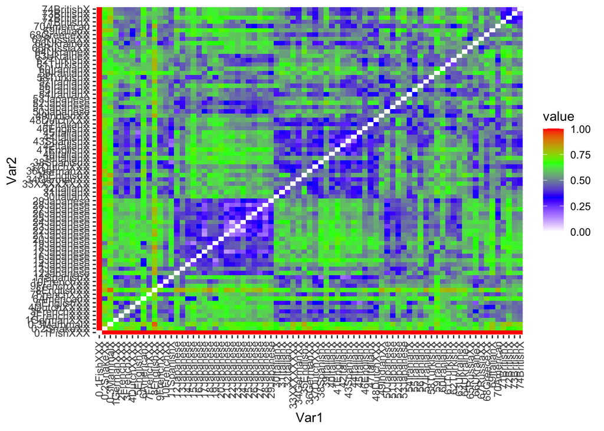

```r
library(ggplot2)
ggplot(data = PDat, aes(x=Var1, y=Var2, fill=value)) +
  geom_tile()+scale_fill_gradientn(colours=c("white","blue","green","red")) +
  theme(axis.text.x = element_text(angle = 90, hjust = 1, vjust = 0.5))
```

Looks like we have a nice range of values to try to cluster by distance.

# Tree Building

Now that we have a distance matrix, let’s try building a phylogeny using the neighbour-joining (NJ) method.

```r
DragonTree<-nj(DragonDist)
```

Now let’s draw the tree using the `ggtree` library to compare the two:

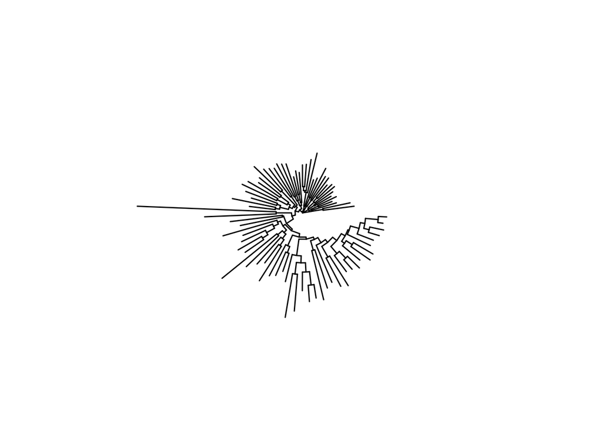

```r
library(ggtree)
ggtree(DragonTree,layout="circular")
```

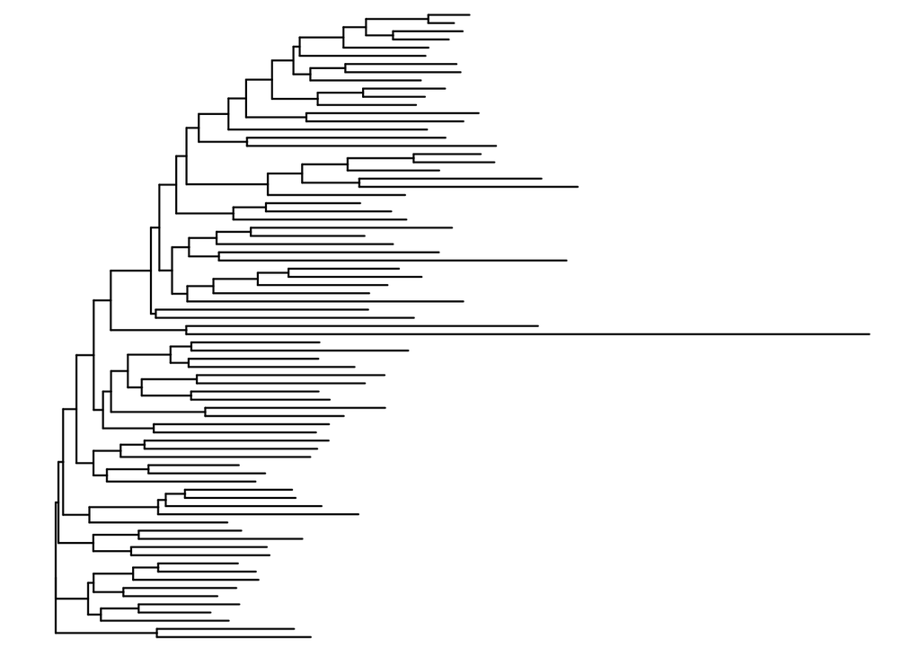

```r
ggtree(DragonTree,layout="rectangular")
```

> Woah, what’s going on here?

This tree has some problems. The branches are very long relative to the bifurcations among groups. It is almost as if all the characters are all mixed up. This is what we might expect if dragons were created from active imaginations and didn’t really evolve from each other.

Another reason is that we are treating all traits the same. For example, we treat snout length the same as limb number. However, we might argue that limb length evolves more slowly than snout length, that dragons with the same number of limbs are more likely related than dragons with similar snout lengths. We can do this by weighting our traits. Weights are just numbers that we multiply (or sometimes add) to our data so that traits with higher weights have a stronger influence on our clustering algorithm.

# Weights

The Weights.csv data table has a set of weights that were used for the Dragon Phylogeny t-shirt design. Let’s take a look:

```r
WeightsDat<-read.csv("Data/Weights.csv")
```

| Code | Origin | Weight | Rationale |
| --- | --- | --- | --- |
| 1 | Appendages | ZZZZ | Highly Highly conserved (all tertrapods came from the same fish; loss of limbs more common (e.g. lizards to snakes) |
| 2 | Mass | 1111 | Weak: e.g. squirrel vs. Kangaroo |
| 3 | Body Type | CC | Body type somewhat conserved (e.g. snakes vs. lizards) |
| 4 | ClawType | 5555 | Somewhat Strong: e.g. mammals vs. eagle |
| 5 | Dorsal Ridges | 111111 | Weak: e.g. dinosaurs |
| 6 | Ear Morphology | 111 | Weak: e.g. deer mouse vs. vole |
| 7 | Eye Morphology | 111 | Weak: e.g. nocturnal vs. diurnal and eye size |
| 8 | Eye Position | 1 | Weak: e.g. predators vs. prey |
| 9 | HornType | 111 | Weak: e.g. gazelle vs. deer |
| 10 | NosePos | 7 | Moderately conserved e.g. amphibians vs. fish |
| 11 | Nasal Morphology | 1 | Weak: e.g. dog breeds |
| 12 | Skin-dorsal | 999999 | Somewhat conserved: e.g. reptiles vs. mammals |
| 13 | Skin-head | 333333 | Somewhat conserved: e.g. reptiles vs. mammals |
| 14 | Skin-ventral | 333333 | Somewhat conserved: e.g. reptiles vs. mammals |
| 15 | SnoutType | 3333 | Moderate: e.g. mouse vs. rhinocerous |
| 16 | TailType | 11 | Weak: e.g. dinosaurs |
| 17 | Teeth | 3333 | Moderately conserved e.g. herbivore vs. carnivore mammals |
| 18 | OppToes | 1 | Weak: e.g. chimps vs. humans |
| 19 | Toe Number | 333333 | Moderate: e.g. horse vs. lion |
| 20 | Tongue Length | 1 | Weak: e.g. anteater vs. primate |
| 21 | Tongue Morphology Type | 44 | Moderate: e.g. snake vs. lizard |
| 22 | Ventral Plates | 7 | Somewhat conserved: e.g. snakes vs. mammals |
| 23 | Wiskers | 11 | Weak: e.g. catfish vs. bass |
| 24 | Wing Structure | JJ | Somewhat highly conserved; single origin in bats and birds |
| 25 | WingType | AAA | Strong: e.g. bat vs. bird |

Weights are scaled on a scale from 1 through 9 and then A (A=10) through Z (Z=35). The number of each digit corresponds to the number of binary values for that trait, and the traits are ordered in the same way they were encoded. There are programs we could use to calculate distance using these as weights (e.g. [BEAST2](http://www.beast2.org/)). However, we’ll do it manually to see how it works. All we need to do is multiply each binary value by it’s weight. So the first step is to import the weights and extract the weights column. However, that’s going to take a few steps:

1. Create a single vector of weights
2. Convert each letter to its corresponding weight value (e.g. A=10, B=11, etc.)
3. Multiply the weight value by the trait vector for each dragon
4. Re-calculate our distance matrix
5. Plot the tree

## 1. Create a single vector of weights.

Easy:

```r
Weights<-paste0(WeightsDat$Weight,collapse="")
Weights<-strsplit(Weights,split="")[[1]]
```

## 2. Convert each letter to a value.

We could encode very single letter individually, or we can use a custom function with the built-in `LETTERS` object:

```r
LETTERS # See what LETTERS is (see also letters)
```

```
##  [1] "A" "B" "C" "D" "E" "F" "G" "H" "I" "J" "K" "L" "M" "N" "O" "P" "Q" "R" "S"
## [20] "T" "U" "V" "W" "X" "Y" "Z"
```

```r
which(LETTERS=="G")
```

```
## [1] 7
```

```r
WeightsNum<-rep(NA,length(Weights))
for(i in 1:length(WeightsNum)){
  if(Weights[i] %in% LETTERS){
    WeightsNum[i]<-which(LETTERS==Weights[i])+9
  } else {
    WeightsNum[i]<-Weights[i]
  }
}
WeightsNum<-as.numeric(WeightsNum)
```

Now we have a vector of weights, which should have the same length as the number of 1s and 0s (i.e. 78 ‘characters’):

```r
length(WeightsNum)
```

```
## [1] 78
```

## 3. Multiply the weight value by the trait vector for each dragon.

This is complicated by the fact that our data include missing data coded as `?`, so all of our characters are stored as strings. Since $0*x=0$ and $?*x$ is undefinded, we really just need to multiply the 1s, which is equivalent to replacing the 1s with their corresponding weight values. To do this, we also have to **slice** our list object using the double brackets `[[]]`.

```r
WtDragonNexus<-DragonNexus # Make a new weighted data frame object
for (i in 1:length(DragonNexus)){
  RepWeight<-DragonNexus[[i]]==1
  WtDragonNexus[[i]][RepWeight]<-WeightsNum[RepWeight]
  RepWeight<-NA
}
```

## 4. Re-calculate our distance matrix

We just need to modify our objects

```r
WtDragonNexusDF<-data.frame(matrix(unlist(WtDragonNexus),ncol=78,byrow=T))
row.names(WtDragonNexusDF)<-names(WtDragonNexus)
WtDragonDist<-dist(WtDragonNexusDF,method='euclidean')
WtDragonDistMat<-as.matrix(WtDragonDist)
```

> Note the change in method from binary to euclidean… why?

Compare the new distance matrix to the older one above. Note the much stronger structure:

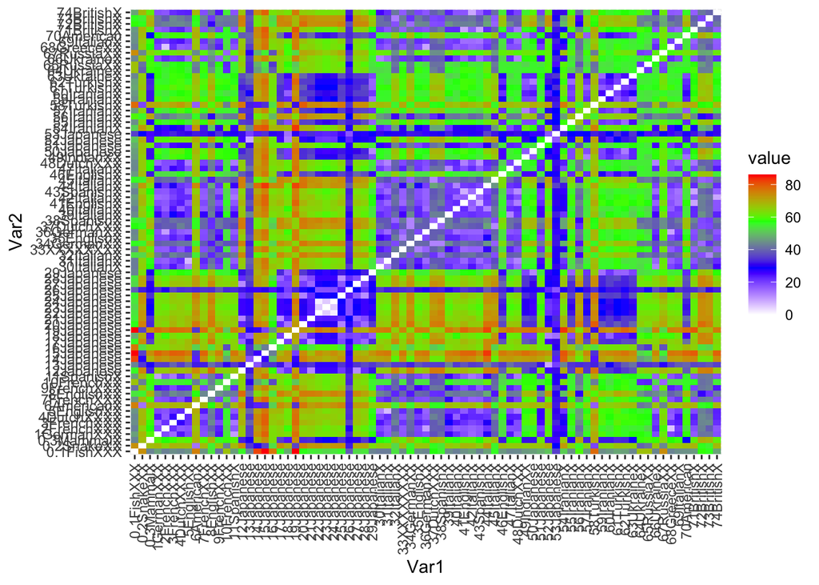

```r
WtPDat<-melt(WtDragonDistMat)
ggplot(data = WtPDat, aes(x=Var1, y=Var2, fill=value)) +
  geom_tile()+scale_fill_gradientn(colours=c("white","blue","green","red")) +
  theme(axis.text.x = element_text(angle = 90, hjust = 1, vjust = 0.5))
```

## 5. Plot the tree

Let’s compare the minimal evolution (ME) and Neighbour Joining (NJ) methods

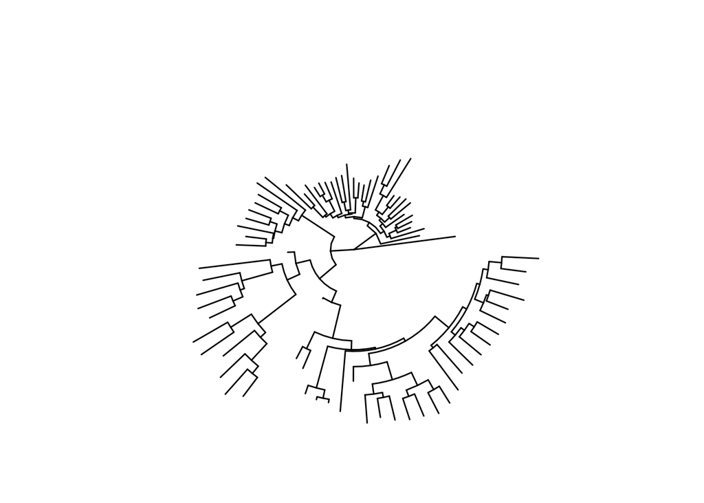

```r
WtDragonTree<-fastme.bal(WtDragonDist)
WtDragonTreeNJ<-nj(WtDragonDist)
ggtree(WtDragonTree,layout="circular")
```

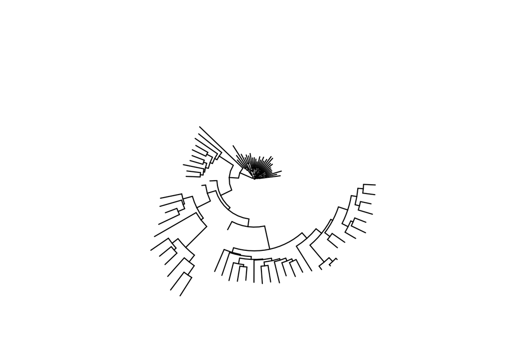

```r
ggtree(WtDragonTreeNJ,layout="circular")
```

# Tree Formatting

Let’s try to make it look a bit better. To do this, we need to understand the data format

```r
str(WtDragonTree)
```

```
## List of 4
##  $ edge       : int [1:151, 1:2] 78 78 79 80 81 81 82 83 83 82 ...
##  $ edge.length: num [1:151] 25.6 5.88 9.8 1.63 12.13 ...
##  $ tip.label  : chr [1:77] "0.1FishXXX" "8EnglishXX" "32ItalianX" "73BritishX" ...
##  $ Nnode      : int 75
##  - attr(*, "class")= chr "phylo"
##  - attr(*, "order")= chr "cladewise"
```

> Q: Why are there 151 edges if we only have 77 dragons?

The edges include lines that connect clades.

## Colour by OTU

```r
head(WtDragonTree$tip.label)
```

```
## [1] "0.1FishXXX" "8EnglishXX" "32ItalianX" "73BritishX" "37DutchXXX"
## [6] "45ItalianX"
```

We can use this to colour-code our tree and see if dragons from the same regions cluster together. We can use regular expressions to parse out a vector:

```r
Country<-gsub("[0-9\\.]+([^X]+)X*","\\1",WtDragonTree$tip.label) # Remove leading numbers
```

Next we have to group `tip.labels` by their corresponding country. There is a nice function in R called `split` that makes this easy to do:

```r
CountryGroups<-split(WtDragonTree$tip.label, Country)
```

Now we use the `groupOTU` function to apply the grouping information for plotting:

```r
WtDTcol<-groupOTU(WtDragonTree,CountryGroups)
str(WtDTcol)
```

```
## List of 4
##  $ edge       : int [1:151, 1:2] 78 78 79 80 81 81 82 83 83 82 ...
##  $ edge.length: num [1:151] 25.6 5.88 9.8 1.63 12.13 ...
##  $ tip.label  : chr [1:77] "0.1FishXXX" "8EnglishXX" "32ItalianX" "73BritishX" ...
##  $ Nnode      : int 75
##  - attr(*, "class")= chr "phylo"
##  - attr(*, "order")= chr "cladewise"
##  - attr(*, "group")= Factor w/ 19 levels "3","American",..: 6 5 12 3 4 12 8 17 3 11 ...
```

Notice how there is a new `group` attribute, which is a factor containing our country groups.

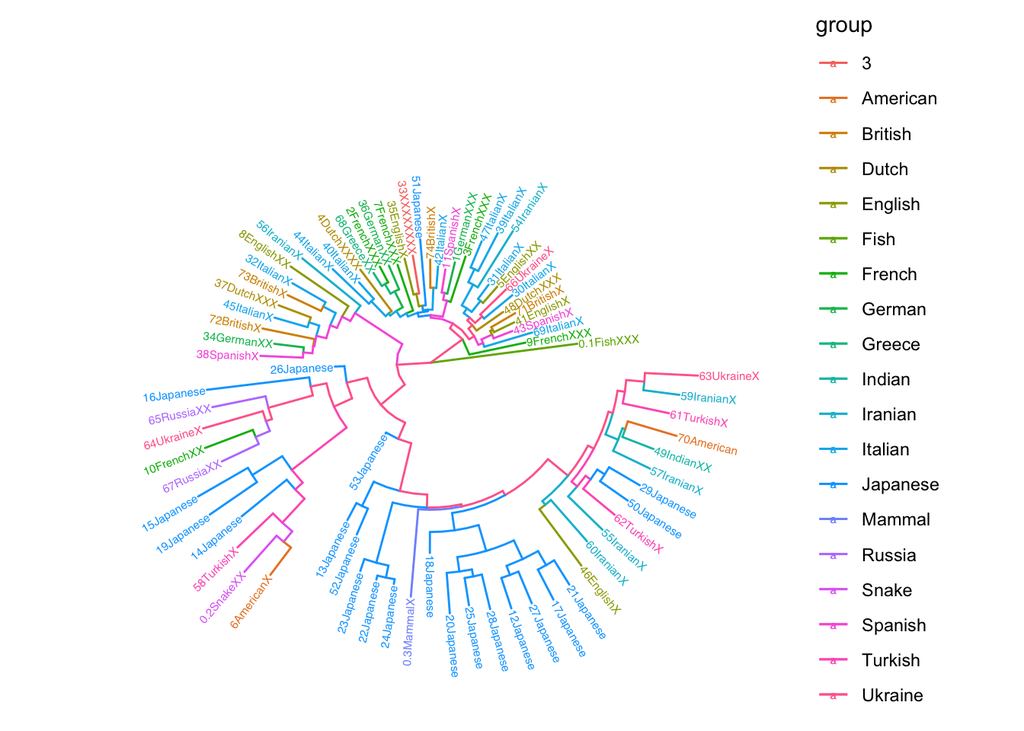

```r
ggtree(WtDTcol,layout="circular",aes(colour=group))+geom_tiplab(size=2,aes(angle=angle))
```

> What might we infer from this figure?

## Colour by clade

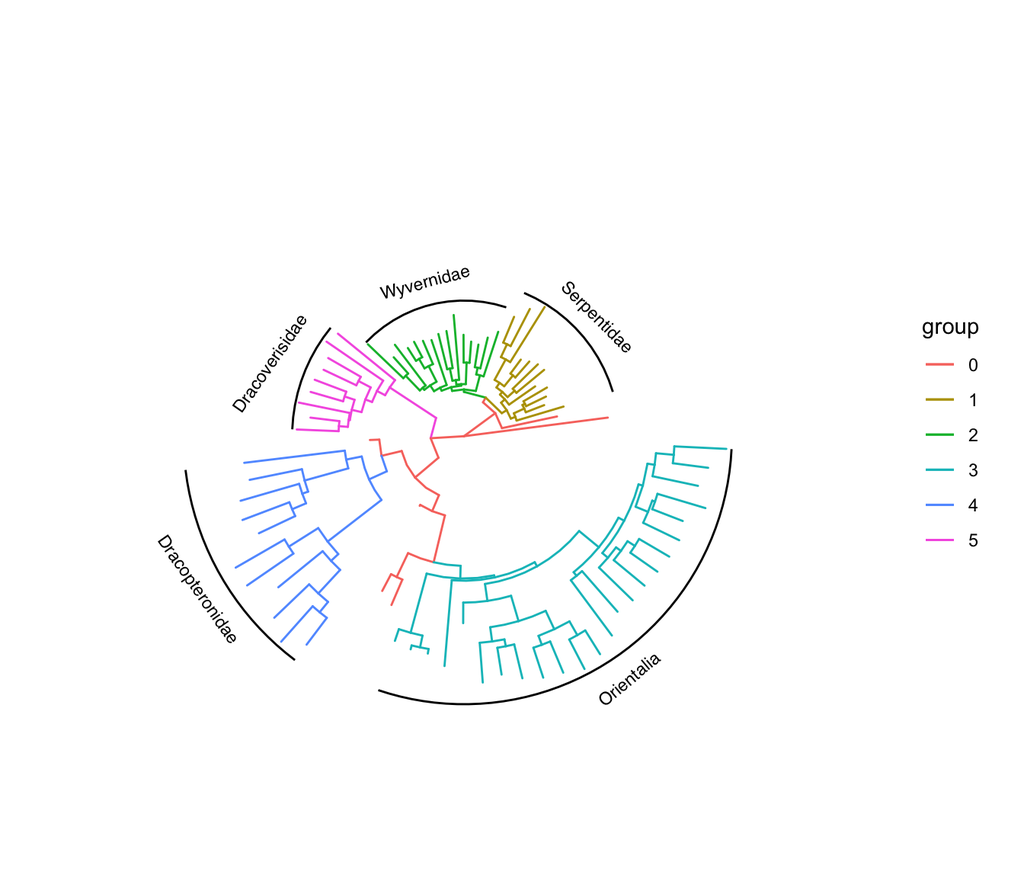

```r
WtDTclade<-groupClade(WtDragonTree,.node=c(142,128,103,90,80))
ggtree(WtDTclade,layout="circular",aes(colour=group)) +
  geom_cladelabel(node=142,label="Serpentidae",hjust=0.5,offset.text=4,fontsize=3,angle=-45) +
  geom_cladelabel(node=128,label="Wyvernidae",hjust=0.5,offset.text=4,fontsize=3,angle=15) +
  geom_cladelabel(node=103,label="Orientalia",hjust=0.5,offset.text=4,fontsize=3,angle=40) +
  geom_cladelabel(node=90,label="Dracopteronidae",hjust=0.5,offset.text=4,fontsize=3,angle=-55) +
  geom_cladelabel(node=80,label="Dracoverisidae",hjust=0.5,offset.text=6,fontsize=3,angle=55) +
  xlim(NA,60)
```

# Advanced Techniques:

Try overlaying your phylogeny on a geographical map: https://www.molecularecologist.com/2014/11/geophylogeny-plots-in-r-for-dummies/